# Scanpy_Tutorial_Cellcraft

**Basic Scanpy Tutorial - (i) preprocessing**

This tutorial serves as the foundational module for producing the input files required for **TENET** gene regulatory network (GRN) analysis.

*Structure.* The tutorial comprises two modules: (i) **preprocessing** and (ii) **generation of TENET inputs**. This page covers Module (i), demonstrating standard preprocessing of scRNA-seq data in Scanpy—quality control (QC), normalization, feature selection, dimensionality reduction, clustering, and differential expression (DEG) analysis.

*Already preprocessed data?* If your scRNA-seq data have already been preprocessed, you may skip Module (i) and proceed directly to the relevant workflow:

- **Seurat/Monocle tutorial:** https://cellcraft.app/tutorial?htmlName=monocle
- **Scanpy/PAGA tutorial:** https://cellcraft.app/tutorial?htmlName=PAGA

*Data and pipeline.* We begin with count data generated by **Cell Ranger** and proceed through a standard Scanpy workflow. For illustration, we use a publicly available **Peripheral Blood Mononuclear Cell (PBMC)** dataset from **10x Genomics**.

# Index

**1. Setup**  
**1-1. Data Download**  
**1-2. Setting Up the Environment**  
**1-3. Data Load and Save**

**2. Preprocessing**  
**2-1. Basic filtering**  
**2-2. Quality Control**  
**2-3. Normalization and Logarithmize**

**3. Dimension Reduction**  
**3-1. Feature Selection**  
**3-2. Data Scaling**  
**3-3. PCA**

**4. Differentially Expressed Genes Analysis**  
**4-1. Clustering**  
**4-2. UMAP**  
**4-3. Finding Marker Genes**

**5. Annotation**  
**5-1. Define a list of Marker Genes**  
**5-2. Visulaization**  
**5-3. Save the result**  
___

## 1. Setup

Return to Index

This process consists of steps from data download to setting up the analysis environment and separating the Tenet input. Data is in AnnData format, and various variables should be adjusted according to your specific data, so I recommend referring to the Scanpy website for detailed instructions.

##### Additionally, the Structure of AnnData is as follows.

[figure not shown]

### 1-1. Data Download

Download the data in the terminal environment before proceeding with the setup. For detailed instructions, refer to the following code. The data consists of 3k PBMCs obtained from a healthy donor and is available through 10x Genomics. The data is structured as a **2700 x 32738 Matrix** of cells by genes.

```python
# !mkdir data
# !wget http://cf.10xgenomics.com/samples/cell-exp/1.1.0/pbmc3k/pbmc3k_filtered_gene_bc_matrices.tar.gz -O data/pbmc3k_filtered_gene_bc_matrices.tar.gz
# !cd data; tar -xzf pbmc3k_filtered_gene_bc_matrices.tar.gz
# !mkdir write
```

### 1-2. Setting Up the Environment

```python
import numpy as np
import pandas as pd
import scanpy as sc
import warnings
warnings.filterwarnings("ignore")
```

Set the verbosity level and configure the resolution, size, style, and format of the figures.

```python
sc.settings.verbosity = 3
sc.logging.print_header()
sc.settings.set_figure_params(dpi=80, facecolor='white')
```

```
scanpy==1.9.6 anndata==0.9.2 umap==0.5.5 numpy==1.24.4 scipy==1.10.1 pandas==2.0.3 scikit-learn==1.3.2 statsmodels==0.14.0 igraph==0.10.8 louvain==0.8.1 pynndescent==0.5.11
```

### 1-3. Data Load and Save

Load the count matrix into an AnnData object, which provides various slots for annotations and different data representations. Additionally, AnnData comes with its own file format based on HDF5 : **h5ad**

```python
results_file = '/home/Users/write/pbmc3k.h5ad' # your directory
```

```python
adata = sc.read_10x_mtx(
    '/home/Users/filtered_gene_bc_matrices/hg19/',
    var_names='gene_symbols',
    cache=True)
```

```
... reading from cache file cache/home-Data_Drive_8TB-khcho-Data_Drive_8TB_3-Cellcraft-filtered_gene_bc_matrices-hg19-matrix.h5ad
```

This process combines duplicate genes into a single one, in other words, it makes variable names unique.

```python
adata.var_names_make_unique()
```

## 2. Preprocessing

Return to Index

Before diving into the actual analysis, several QC steps are undertaken. In this tutorial, there are roughly three main processes, each as follows. Before following the code and proceeding with the tutorial, it is recommended that you determine your own QC criteria based on your own judgment and experience, as they may vary depending on your specific dataset.

> - `Basic filtering`
> - `Quality control`
> - `Normalization and Logarithmize`

___

This process is finding the top 20 highly expressed genes.

```
normalizing counts per cell
    finished (0:00:00)
```

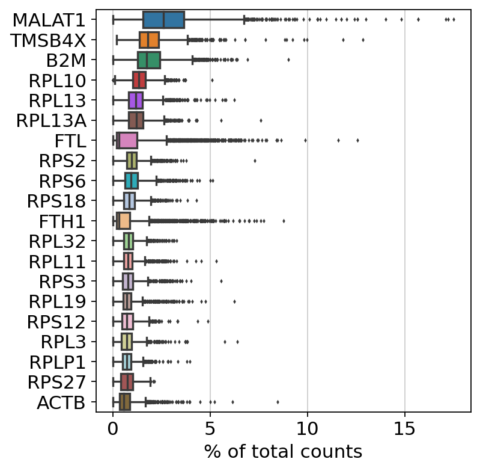

```python
sc.pl.highest_expr_genes(adata, n_top=20, )
```

### 2-1. Basic filtering

We perform cell filtering based on the number of expressed genes and counts, as well as gene filtering based on the number of cells or counts. This process is conducted to filter out unreliable observations, as cells with too few counts are considered to be dying cells.

```python
sc.pp.filter_cells(adata, min_genes=200)
sc.pp.filter_genes(adata, min_cells=3)
```

```
filtered out 19024 genes that are detected in less than 3 cells
```

### 2-2. Quality Control

We conduct QC to **Remove Low-Quality** data. We calculate the QC matrix, and if a high number of mitochondrial genes are detected, we consider these cells to be dying and remove them. Low counts and genes also indicate cells that have not progressed well, so we filter them out based on specific criteria.

```python
adata.var['mt'] = adata.var_names.str.startswith('MT-')
sc.pp.calculate_qc_metrics(adata, qc_vars=['mt'], percent_top=None, log1p=False, inplace=True)
```

The rightmost plot represents the proportion of mitochondrial genes.

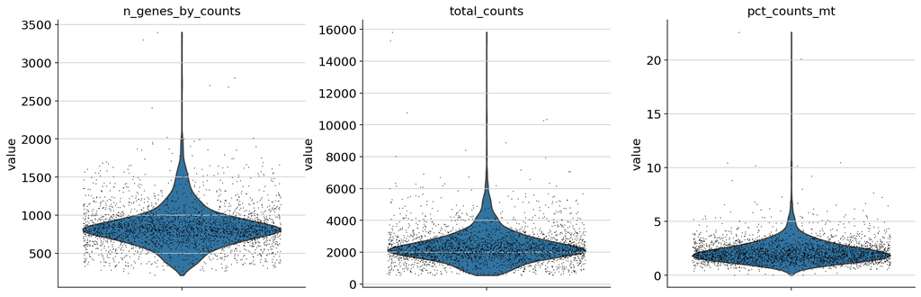

```python
sc.pl.violin(adata, ['n_genes_by_counts', 'total_counts', 'pct_counts_mt'],
             jitter=0.4, multi_panel=True)
```

This Scatter plot has been generated to visualize feature-feature relationships.

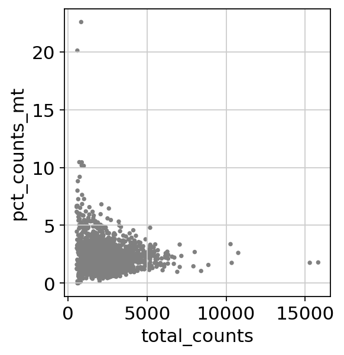

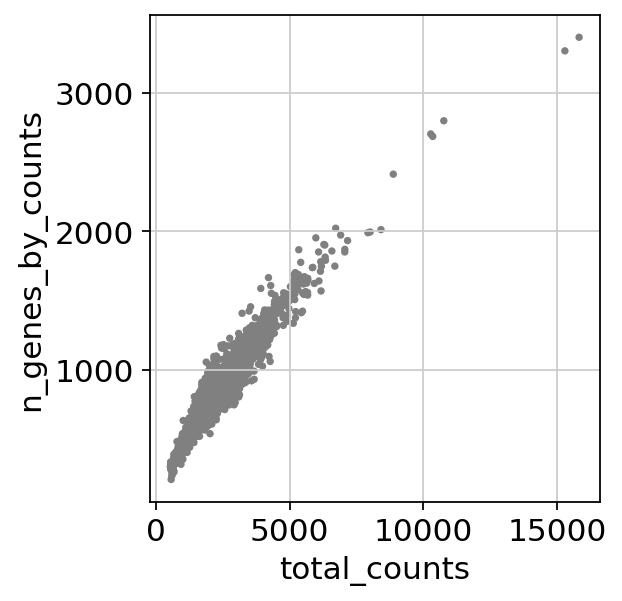

```python
sc.pl.scatter(adata, x='total_counts', y='pct_counts_mt')
sc.pl.scatter(adata, x='total_counts', y='n_genes_by_counts')
```

```python
adata = adata[adata.obs.n_genes_by_counts < 2500, :]
adata = adata[adata.obs.pct_counts_mt < 5, :]
```

Designate the **Raw Count matrix** separately as input for Tenet. This is because Scanpy does not save separately, and the term 'raw data' mentioned here refers to Logarithmized data.

```python
adata.layers["counts"] = adata.X.copy()
adata.layers['counts'].todense()
```

```
matrix([[0., 0., 0., ..., 0., 0., 0.],
        [0., 0., 0., ..., 0., 0., 0.],
        [0., 0., 0., ..., 0., 0., 0.],
        ...,
        [0., 0., 0., ..., 0., 0., 0.],
        [0., 0., 0., ..., 1., 0., 0.],
        [0., 0., 0., ..., 0., 0., 0.]], dtype=float32)
```

```python
raw_count_matrix = pd.DataFrame(adata.layers['counts'].todense()
                                , index=adata.obs_names, columns=adata.var_names)
raw_count_matrix
```

|  | AL627309.1 | AP006222.2 | RP11-206L10.2 | RP11-206L10.9 | LINC00115 | NOC2L | KLHL17 | PLEKHN1 | RP11-54O7.17 | HES4 | ... | MT-ND4L | MT-ND4 | MT-ND5 | MT-ND6 | MT-CYB | AC145212.1 | AL592183.1 | AL354822.1 | PNRC2-1 | SRSF10-1 |
| --- | --- | --- | --- | --- | --- | --- | --- | --- | --- | --- | --- | --- | --- | --- | --- | --- | --- | --- | --- | --- | --- |
| AAACATACAACCAC-1 | 0.0 | 0.0 | 0.0 | 0.0 | 0.0 | 0.0 | 0.0 | 0.0 | 0.0 | 0.0 | ... | 0.0 | 10.0 | 1.0 | 0.0 | 4.0 | 0.0 | 0.0 | 0.0 | 0.0 | 0.0 |
| AAACATTGAGCTAC-1 | 0.0 | 0.0 | 0.0 | 0.0 | 0.0 | 0.0 | 0.0 | 0.0 | 0.0 | 0.0 | ... | 0.0 | 33.0 | 1.0 | 0.0 | 8.0 | 0.0 | 1.0 | 0.0 | 0.0 | 0.0 |
| AAACATTGATCAGC-1 | 0.0 | 0.0 | 0.0 | 0.0 | 0.0 | 0.0 | 0.0 | 0.0 | 0.0 | 0.0 | ... | 0.0 | 3.0 | 2.0 | 0.0 | 4.0 | 0.0 | 0.0 | 0.0 | 0.0 | 0.0 |
| AAACCGTGCTTCCG-1 | 0.0 | 0.0 | 0.0 | 0.0 | 0.0 | 0.0 | 0.0 | 0.0 | 0.0 | 0.0 | ... | 1.0 | 3.0 | 2.0 | 0.0 | 2.0 | 0.0 | 0.0 | 0.0 | 0.0 | 0.0 |
| AAACCGTGTATGCG-1 | 0.0 | 0.0 | 0.0 | 0.0 | 0.0 | 0.0 | 0.0 | 0.0 | 0.0 | 0.0 | ... | 0.0 | 0.0 | 2.0 | 0.0 | 1.0 | 0.0 | 0.0 | 0.0 | 0.0 | 0.0 |
| ... | ... | ... | ... | ... | ... | ... | ... | ... | ... | ... | ... | ... | ... | ... | ... | ... | ... | ... | ... | ... | ... |
| TTTCGAACTCTCAT-1 | 0.0 | 0.0 | 0.0 | 0.0 | 0.0 | 0.0 | 0.0 | 0.0 | 0.0 | 0.0 | ... | 0.0 | 1.0 | 0.0 | 0.0 | 1.0 | 0.0 | 0.0 | 0.0 | 0.0 | 0.0 |
| TTTCTACTGAGGCA-1 | 0.0 | 0.0 | 0.0 | 0.0 | 0.0 | 0.0 | 0.0 | 0.0 | 0.0 | 0.0 | ... | 1.0 | 2.0 | 1.0 | 0.0 | 4.0 | 0.0 | 0.0 | 0.0 | 0.0 | 0.0 |
| TTTCTACTTCCTCG-1 | 0.0 | 0.0 | 0.0 | 0.0 | 0.0 | 0.0 | 0.0 | 0.0 | 0.0 | 0.0 | ... | 0.0 | 7.0 | 0.0 | 0.0 | 4.0 | 0.0 | 0.0 | 0.0 | 0.0 | 0.0 |
| TTTGCATGAGAGGC-1 | 0.0 | 0.0 | 0.0 | 0.0 | 0.0 | 0.0 | 0.0 | 0.0 | 0.0 | 0.0 | ... | 1.0 | 0.0 | 0.0 | 0.0 | 1.0 | 0.0 | 0.0 | 1.0 | 0.0 | 0.0 |
| TTTGCATGCCTCAC-1 | 0.0 | 0.0 | 0.0 | 0.0 | 0.0 | 0.0 | 0.0 | 0.0 | 0.0 | 0.0 | ... | 0.0 | 1.0 | 0.0 | 0.0 | 3.0 | 0.0 | 0.0 | 0.0 | 0.0 | 0.0 |

2638 rows × 13714 columns

### 2-3. Normalization and Logarithmize

scRNA sequencing often has a high number of zero counts, making it necessary to apply appropriate normalization methods.

```python
sc.pp.normalize_total(adata, target_sum=1e4)
sc.pp.log1p(adata)
```

```
normalizing counts per cell
    finished (0:00:00)
```

# 3. Dimension Reduction

Return to Index

It can be challenging to analyze an extensive number of genes comprehensively. Therefore, we select important genes and undergo a dimensionality reduction process using this gene subset. The criteria for selecting important genes, which we will explain later, often rely on Standard Deviation. Genes with high STD are referred to as Highly Variable genes (HVGs), and we continue the analysis using this group.

___

### 3-1. Feature Selection

To select important genes, we choose genes with high STD. Typically, 1000 to 5000 highly variable genes **(HVGs)** are selected. From this point onwards, since we will be working with HVGs, a separate process for storing raw data is necessary. We will describe this later.

```
extracting highly variable genes
    finished (0:00:00)
--> added
    'highly_variable', boolean vector (adata.var)
    'means', float vector (adata.var)
    'dispersions', float vector (adata.var)
    'dispersions_norm', float vector (adata.var)
```

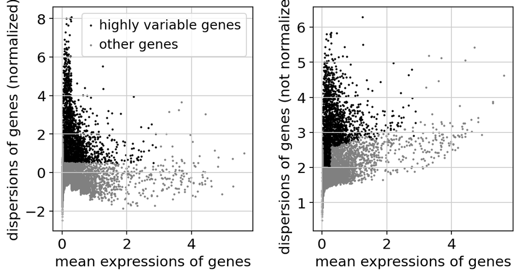

```python
sc.pp.highly_variable_genes(adata, min_mean=0.0125, max_mean=3, min_disp=0.5)
sc.pl.highly_variable_genes(adata)
```

### 3-2. Data Scaling

This process is storing the **Normalized and Logarithmized Data** separately and using only the highly-variable genes to reduce and work.

```python
adata.raw = adata
adata = adata[:, adata.var.highly_variable]
```

Perform **Regression** using total count and MT count and **Data Scaling**. This process is not include in Seurat.

```python
sc.pp.regress_out(adata, ['total_counts', 'pct_counts_mt'])
sc.pp.scale(adata, max_value=10)
```

```
regressing out ['total_counts', 'pct_counts_mt']
    sparse input is densified and may lead to high memory use
    finished (0:00:03)
```

### 3-3. PCA

In PCA, we utilize **Principal Components**, which are new variables created by linear combinations of the expression levels of the selected genes from feature selection. It can be used as a pre-processing step for non-linear dimensionality reduction methods.

```
computing PCA
    on highly variable genes
    with n_comps=50
    finished (0:00:00)
```

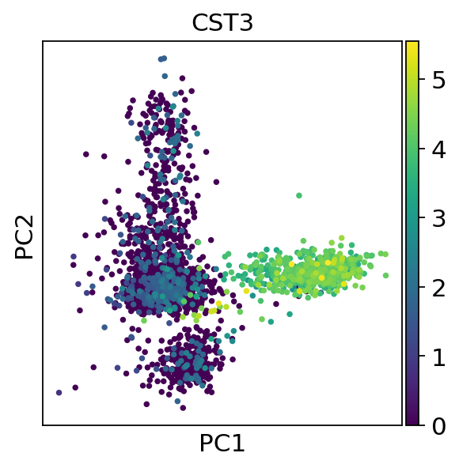

```python
sc.tl.pca(adata, svd_solver='arpack')
sc.pl.pca(adata, color='CST3')
```

Heuristically, the elbow method is used to determine how many principal components to use in PCA.

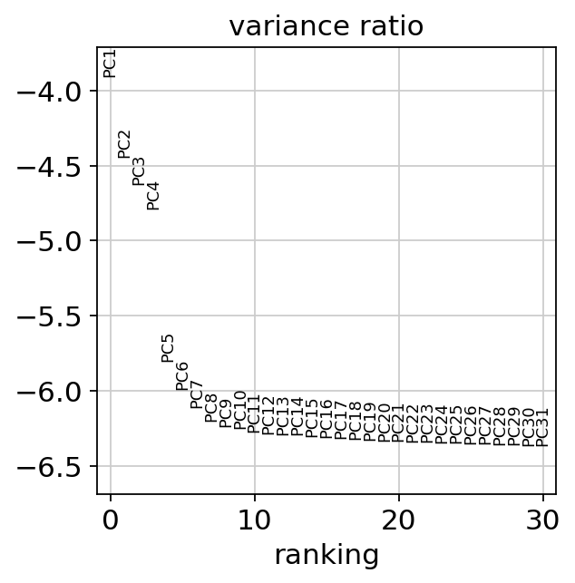

```python
sc.pl.pca_variance_ratio(adata, log=True)
```

# 4. Differentially Expressed Genes Analysis

Return to Index

In this process, we proceed with the next steps, such as UMAP, based on the results of clustering. Therefore, it's crucial for the **User to Determine How many PCA** to use by observing the elbow graph in the previous steps before performing clustering. After clustering, we hope to identify Differentially Expressed Genes successfully.

___

### 4-1. Clustering

Clustering is performed **Using Neighbors** as part of the process for cell type annotation. This step is crucial because well-done clustering is essential for the success of subsequent analyses.

```python
sc.pp.neighbors(adata, n_neighbors=10, n_pcs=40)
```

```
computing neighbors
    using 'X_pca' with n_pcs = 40
    finished: added to `.uns['neighbors']`
    `.obsp['distances']`, distances for each pair of neighbors
    `.obsp['connectivities']`, weighted adjacency matrix (0:00:02)
```

### 4-2. UMAP

UMAP and t-SNE are both tools developed for visualization. They can describe the dataset in 2D or 3D. However, t-SNE has limitations in preserving large-scale information such as cluster relationships. In other words, t-SNE may not capture the global structure effectively. Therefore, UMAP is used to **Divide Cell Types and Visualize where the Samples Originate from**.

> - `use_raw=False`

```
computing UMAP
    finished: added
    'X_umap', UMAP coordinates (adata.obsm) (0:00:02)
```

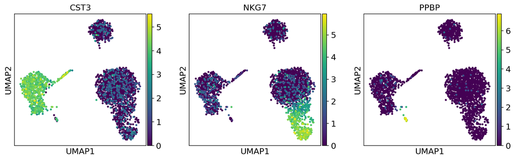

```python
sc.tl.umap(adata)
sc.pl.umap(adata, color=['CST3', 'NKG7', 'PPBP'])
```

Use the Leiden algorithm, an improved version of the Louvain algorithm. Leiden graph-clustering method is community detection based on optimizing modularity.

```
running Leiden clustering
    finished: found 8 clusters and added
    'leiden', the cluster labels (adata.obs, categorical) (0:00:00)
```

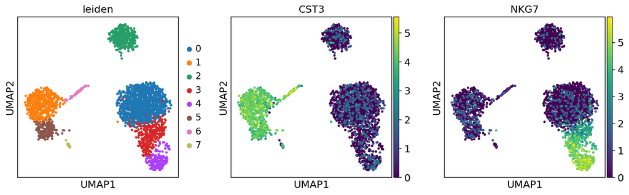

```python
sc.tl.leiden(adata)
sc.pl.umap(adata, color=['leiden', 'CST3', 'NKG7'])
```

### 4-3. Finding Marker Genes

Marker genes are meaningful **Biological Labels** that characteristics of clusters. To identify such marker genes, we conduct differential expression testing. This involves comparing the cells from one specific cluster to cells from all other clusters, pair by pair, using the Wilcoxon rank-sum test to find significant differences.

If you want to compare two clusters, please refer to thsi code.

> - `sc.tl.rank_genes_groups(adata, 'leiden', groups=['0'], reference='1', method='wilcoxon')`
> - `sc.pl.rank_genes_groups(adata, groups=['0'], n_genes=20)`

```
ranking genes
    finished: added to `.uns['rank_genes_groups']`
    'names', sorted np.recarray to be indexed by group ids
    'scores', sorted np.recarray to be indexed by group ids
    'logfoldchanges', sorted np.recarray to be indexed by group ids
    'pvals', sorted np.recarray to be indexed by group ids
    'pvals_adj', sorted np.recarray to be indexed by group ids (0:00:01)
```

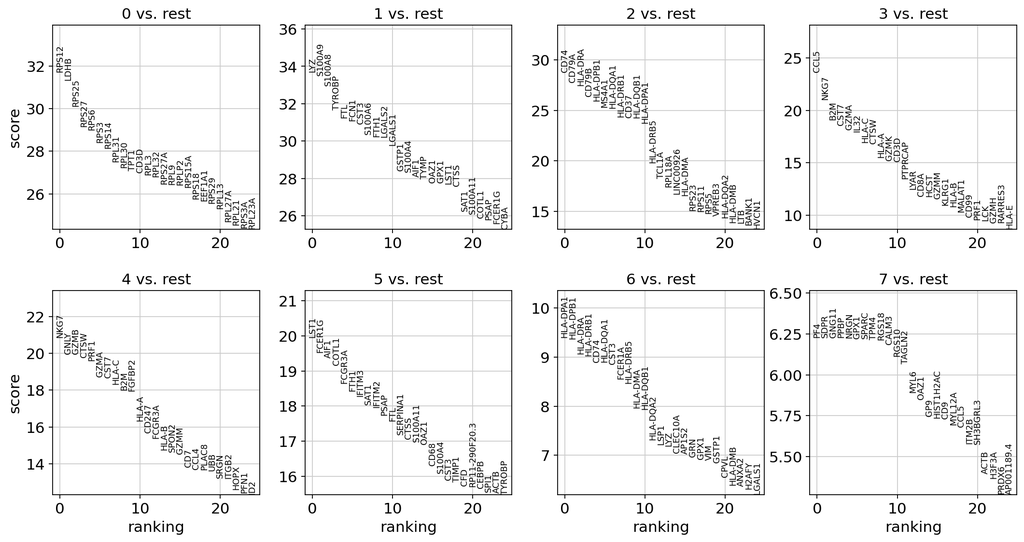

```python
sc.tl.rank_genes_groups(adata, 'leiden', method='wilcoxon')
sc.pl.rank_genes_groups(adata, n_genes=25, sharey=False)
```

The score is a measure from the Wilcoxon rank-sum test, where a higher score indicates a lower p-value and higher expression. We examine the top ranked genes for each of the 8 clusters.

```python
pd.DataFrame(adata.uns['rank_genes_groups']['names']).head(5)
```

|  | 0 | 1 | 2 | 3 | 4 | 5 | 6 | 7 |
| --- | --- | --- | --- | --- | --- | --- | --- | --- |
| 0 | RPS12 | LYZ | CD74 | CCL5 | NKG7 | LST1 | HLA-DPA1 | PF4 |
| 1 | LDHB | S100A9 | CD79A | NKG7 | GNLY | FCER1G | HLA-DPB1 | SDPR |
| 2 | RPS25 | S100A8 | HLA-DRA | B2M | GZMB | AIF1 | HLA-DRA | GNG11 |
| 3 | RPS27 | TYROBP | CD79B | CST7 | CTSW | COTL1 | HLA-DRB1 | PPBP |
| 4 | RPS6 | FTL | HLA-DPB1 | GZMA | PRF1 | FCGR3A | CD74 | NRGN |

# 5. Annotation

Return to Index

By examining the marker genes obtained in the previous steps, you can designate the cell type representative of each cluster. This way, you can specify cell types and create result data that can be utilized when using PAGA later on.

___

### 5-1. Define a list of Marker Genes

Identifying cell types automatically can be challenging, so it is often done **Manually**. Combining the results of DE testing and automated cluster annotation is a common approach that current best parctice. If you are interested in an automated annotation method, please refer to this **[LINK1](https://www.10xgenomics.com/resources/analysis-guides/web-resources-for-cell-type-annotation#web-tools-for-reference-based-automated-cell-type-annotation)**, **[LINK2](https://decoupler-py.readthedocs.io/en/latest/notebooks/cell_annotation.html#Annotation)**.

Whether to merge clusters or keep them is depending on user's judgment. Use can make that judgment based on the heatmap. If you want to merge clusters, please refer to the following code.

> - `adata.obs = adata.obs.replace({'leiden' : 3 } , 0) # cluster 3 is merged into cluster 0.`

```
WARNING: dendrogram data not found (using key=dendrogram_leiden). Running `sc.tl.dendrogram` with default parameters. For fine tuning it is recommended to run `sc.tl.dendrogram` independently.
    using 'X_pca' with n_pcs = 50
Storing dendrogram info using `.uns['dendrogram_leiden']`
```

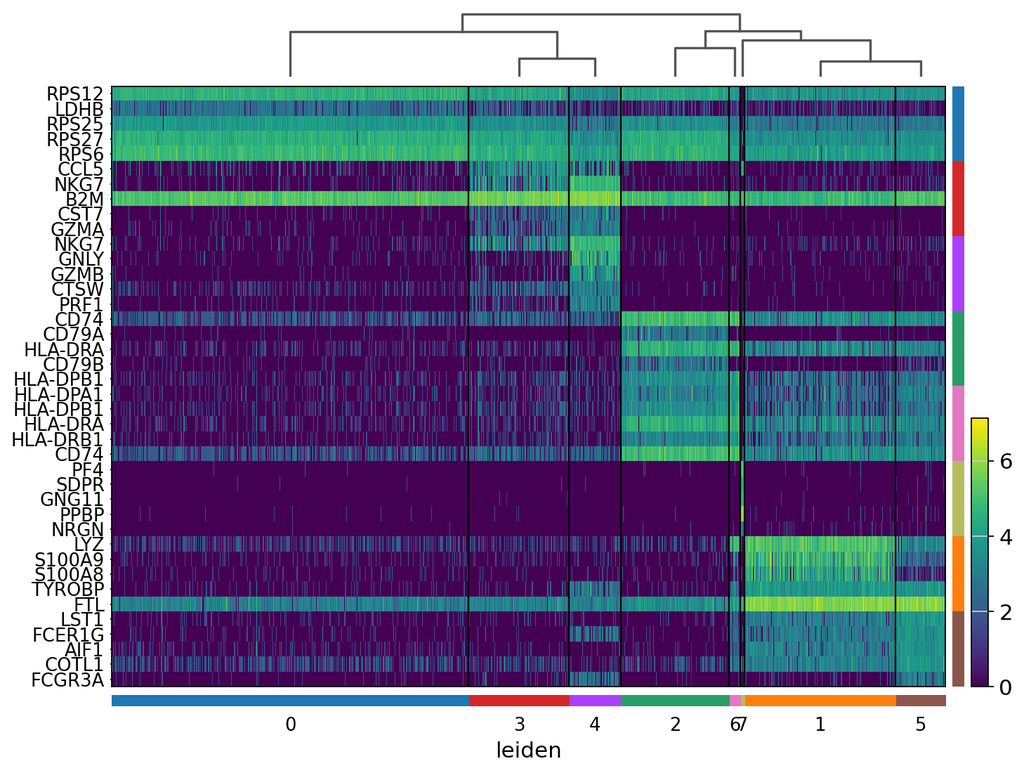

```python
sc.pl.rank_genes_groups_heatmap(adata, n_genes = 5 ,swap_axes=True, key="rank_genes_groups", groupby="leiden")
```

Specify the genes you want to see then you can visualize them as violin plots for various clusters.

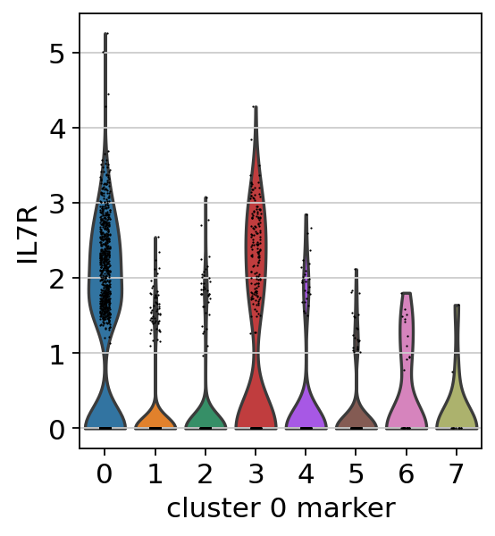

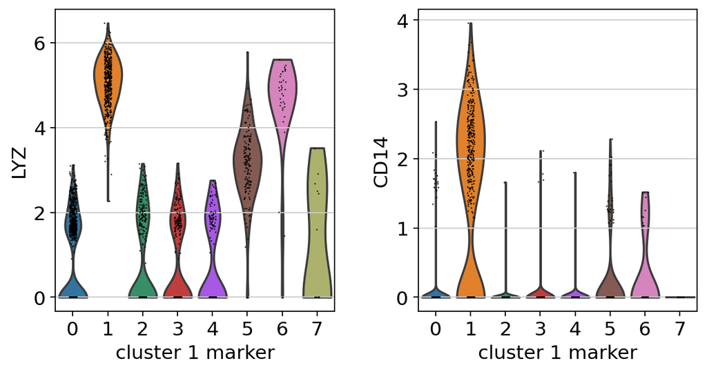

```python
sc.pl.violin(adata, ['IL7R'], groupby='leiden', xlabel = 'cluster 0 marker')
sc.pl.violin(adata, ['LYZ', 'CD14'], groupby='leiden', xlabel = 'cluster 1 marker')
```

Define a list of marker genes. For information on marker genes, please refer to this **[LINK](https://www.10xgenomics.com/resources/analysis-guides/web-resources-for-cell-type-annotation#databases-with-marker-genes-for-manual-annotation)**.

| Louvain Group | Markers | Cell Type |
| --- | --- | --- |
| 0 | IL7R | CD4 T cells |
| 1 | CD14, LYZ | CD14+ Monocytes |
| 2 | MS4A1 | B cells |
| 3 | CD8A | CD8 T cells |
| 4 | GNLY, NKG7 | NK cells |
| 5 | FCGR3A, MS4A7 | FCGR3A+ Monocytes |
| 6 | FCER1A, CST3 | Dendritic Cells |
| 7 | PPBP | Megakaryocytes |

```python
marker_genes = ['IL7R', 'CD79A', 'MS4A1', 'CD8A', 'CD8B', 'LYZ', 'CD14',
                'LGALS3', 'S100A8', 'GNLY', 'NKG7', 'KLRB1',
                'FCGR3A', 'MS4A7', 'FCER1A', 'CST3', 'PPBP']
```

Cell annotation is performed for clusters, and the number of clusters should match the number of cell types being annotated.

```python
new_cluster_names = [
    'CD4 T', 'CD14 Monocytes',
    'B', 'CD8 T',
    'NK', 'FCGR3A Monocytes',
    'Dendritic', 'Megakaryocytes']
adata.rename_categories('leiden', new_cluster_names)
```

### 5-2. Visulaization

Use the annotation results to create UMAP plots, Dot plots, and Stacked Violin Plots.

```
WARNING: saving figure to file figures/umap.pdf
```

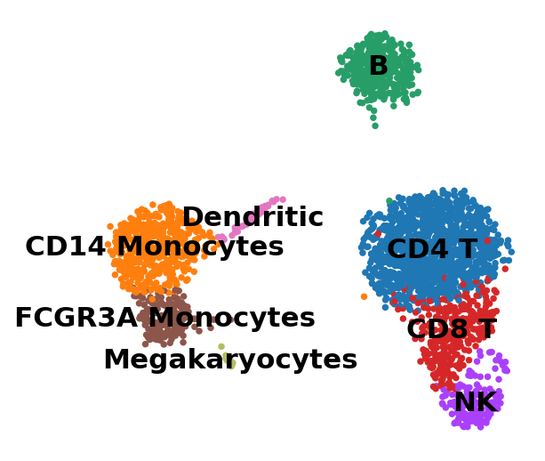

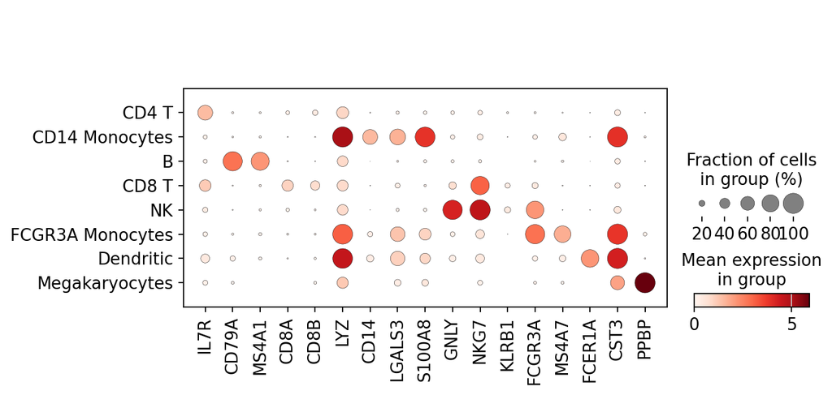

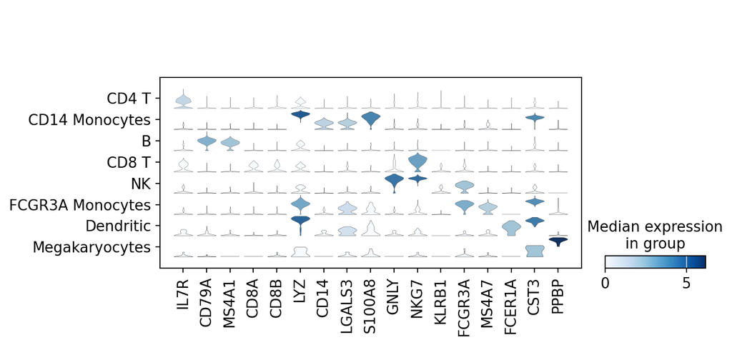

```python
sc.pl.umap(adata, color='leiden', legend_loc='on data', title='', frameon=False, save='.pdf')
sc.pl.dotplot(adata, marker_genes, groupby='leiden');
sc.pl.stacked_violin(adata, marker_genes, groupby='leiden', rotation=90);
```

### 5-3. Save the result

This is the Gene select process for Raw count matrix. We will filter and use genes that meet the specified criteria.

```python
deg_names = pd.DataFrame(adata.uns['rank_genes_groups']['names'])
logfoldchanges = pd.DataFrame(adata.uns['rank_genes_groups']['logfoldchanges'])
pvals_adj = pd.DataFrame(adata.uns['rank_genes_groups']['pvals_adj'])
```

We will filter and use genes that meet the specified criteria.

```python
selected_genes = deg_names[(logfoldchanges >= 0.25) & (pvals_adj <= 0.05)]
Unique_deg_list = selected_genes.stack().unique().tolist()
```

This is Raw Count matrix for Tenet input.

```python
DEG_raw_count_matrix = raw_count_matrix.loc[:, Unique_deg_list]
DEG_raw_count_matrix.to_csv('/home/Users/write/DEG_raw_count_matrix.csv')
```

Save the results file in **h5ad** format.

```python
adata.write(results_file, compression='gzip')
```